# RT optimisation with the Labcyte Echo 525 (3rd plate design)

# RT_PRIMERS

## RT primers concentration

```r
plate %<>%
  set_block("A01~P01",   "RT_PRIMERS",  0.0) %>%
  set_block("A08~P08",   "RT_PRIMERS",  0.0) %>%
  set_block("A15~P15",   "RT_PRIMERS",  0.0) %>%
  set_block("M23",       "RT_PRIMERS",  0.0) %>%
  set_block("P23",       "RT_PRIMERS",  0.0) %>%
  set_block("A02~P02",   "RT_PRIMERS",  0.5) %>%
  set_block("A09~P09",   "RT_PRIMERS",  0.5) %>%
  set_block("A16~P16",   "RT_PRIMERS",  0.5) %>%
  set_block("K22",       "RT_PRIMERS",  0.5) %>%
  set_block("N22",       "RT_PRIMERS",  0.5) %>%
  set_block("A03~P03",   "RT_PRIMERS",  1.0) %>%
  set_block("A10~P10",   "RT_PRIMERS",  1.0) %>%
  set_block("A17~P17",   "RT_PRIMERS",  1.0) %>%
  set_block("K23",       "RT_PRIMERS",  1.0) %>%
  set_block("N23",       "RT_PRIMERS",  1.0) %>%
  set_block("A04~P04",   "RT_PRIMERS",  2.0) %>%
  set_block("A11~P11",   "RT_PRIMERS",  2.0) %>%
  set_block("A18~P18",   "RT_PRIMERS",  2.0) %>%
  set_block("K24",       "RT_PRIMERS",  2.0) %>%
  set_block("N24",       "RT_PRIMERS",  2.0) %>%
  set_block("A05~P05",   "RT_PRIMERS",  4.0) %>%
  set_block("A12~P12",   "RT_PRIMERS",  4.0) %>%
  set_block("A19~P19",   "RT_PRIMERS",  4.0) %>%
  set_block("L22",       "RT_PRIMERS",  4.0) %>%
  set_block("O22",       "RT_PRIMERS",  4.0) %>%
  set_block("A06~P06",   "RT_PRIMERS",  8.0) %>%
  set_block("A13~P13",   "RT_PRIMERS",  8.0) %>%
  set_block("A20~P20",   "RT_PRIMERS",  8.0) %>%
  set_block("L23",       "RT_PRIMERS",  8.0) %>%
  set_block("O23",       "RT_PRIMERS",  8.0) %>%
  set_block("A07~P07",   "RT_PRIMERS", 12.0) %>%
  set_block("A14~P14",   "RT_PRIMERS", 12.0) %>%
  set_block("A21~P21",   "RT_PRIMERS", 12.0) %>%
  set_block("L24",       "RT_PRIMERS", 12.0) %>%
  set_block("O24",       "RT_PRIMERS", 12.0)
```

## RT primer volume

25 nl of RT_PRIMERS added in each well, except the negative controls

```r
plate %<>%
  set_block("A01~P01",   "RT_PRIMERS_vol", 0) %>%
  set_block("A08~P08",   "RT_PRIMERS_vol", 0) %>%
  set_block("A15~P15",   "RT_PRIMERS_vol", 0) %>%
  set_block("M23",       "RT_PRIMERS_vol", 0) %>%
  set_block("P23",       "RT_PRIMERS_vol", 0) %>%
  set_block("A02~P02",   "RT_PRIMERS_vol", 25) %>%
  set_block("A09~P09",   "RT_PRIMERS_vol", 25) %>%
  set_block("A16~P16",   "RT_PRIMERS_vol", 25) %>%
  set_block("K22",       "RT_PRIMERS_vol", 25) %>%
  set_block("N22",       "RT_PRIMERS_vol", 25) %>%
  set_block("A03~P03",   "RT_PRIMERS_vol", 25) %>%
  set_block("A10~P10",   "RT_PRIMERS_vol", 25) %>%
  set_block("A17~P17",   "RT_PRIMERS_vol", 25) %>%
  set_block("K23",       "RT_PRIMERS_vol", 25) %>%
  set_block("N23",       "RT_PRIMERS_vol", 25) %>%
  set_block("A04~P04",   "RT_PRIMERS_vol", 25) %>%
  set_block("A11~P11",   "RT_PRIMERS_vol", 25) %>%
  set_block("A18~P18",   "RT_PRIMERS_vol", 25) %>%
  set_block("K24",       "RT_PRIMERS_vol", 25) %>%
  set_block("N24",       "RT_PRIMERS_vol", 25) %>%
  set_block("A05~P05",   "RT_PRIMERS_vol", 25) %>%
  set_block("A12~P12",   "RT_PRIMERS_vol", 25) %>%
  set_block("A19~P19",   "RT_PRIMERS_vol", 25) %>%
  set_block("L22",       "RT_PRIMERS_vol", 25) %>%
  set_block("O22",       "RT_PRIMERS_vol", 25) %>%
  set_block("A06~P06",   "RT_PRIMERS_vol", 25) %>%
  set_block("A13~P13",   "RT_PRIMERS_vol", 25) %>%
  set_block("A20~P20",   "RT_PRIMERS_vol", 25) %>%
  set_block("L23",       "RT_PRIMERS_vol", 25) %>%
  set_block("O23",       "RT_PRIMERS_vol", 25) %>%
  set_block("A07~P07",   "RT_PRIMERS_vol", 25) %>%
  set_block("A14~P14",   "RT_PRIMERS_vol", 25) %>%
  set_block("A21~P21",   "RT_PRIMERS_vol", 25) %>%
  set_block("L24",       "RT_PRIMERS_vol", 25) %>%
  set_block("O24",       "RT_PRIMERS_vol", 25)
```

# RNA

## RNA concentration

- 0 (controls, + 0 nL) in J01-J21 + K22-K24 + L22-L24 + M23 + N22-N24 + O22-O24 + P23
- 100 ng (+ 25 nL from source well L1 4 ug/uL) in A01-I07
- 10 ng (+ 25 nL from source well L2 400 ng/uL) in A08-I14
- 1 ng (+ 25 nL from source well L3 40 ng/uL) in A15-I21
- 100 pg (+ 25 nL from source well L4 4 ng/uL) in K01-M21
- 10 pg (+ 25 nL from source well L5 0.4 ng/uL) in N01-P21

```r
plate %<>%
  set_block("J01~J21", "RNA", 0)   %>%
  set_block("K22~L24", "RNA", 0)   %>%
  set_block("M23",     "RNA", 0)   %>%
  set_block("N22~O24", "RNA", 0)   %>%
  set_block("P23",     "RNA", 0)   %>%
  set_block("A01~I07", "RNA", 100) %>%
  set_block("A08~I14", "RNA", 10)  %>%
  set_block("A15~I21", "RNA", 1)   %>%
  set_block("K01~M21", "RNA", 0.1) %>%
  set_block("N01~P21", "RNA", 0.01)
```

## RNA volume

25 nL of RNA added to each well, except the negative controls

```r
plate %<>%
  set_block("J01~J21", "RNA_vol", 0)  %>%
  set_block("K22~L24", "RNA_vol", 0)  %>%
  set_block("M23",     "RNA_vol", 0)  %>%
  set_block("N22~O24", "RNA_vol", 0)  %>%
  set_block("P23",     "RNA_vol", 0)  %>%
  set_block("A01~I07", "RNA_vol", 25) %>%
  set_block("A08~I14", "RNA_vol", 25) %>%
  set_block("A15~I21", "RNA_vol", 25) %>%
  set_block("K01~M21", "RNA_vol", 25) %>%
  set_block("N01~P21", "RNA_vol", 25)
```

## RNA group

Wells that will be indexed together, including negative controls with no RNA.

```r
plate %<>%
  set_block("A01~J07", "RNA_group", "100ng") %>%
  set_block("A08~J14", "RNA_group",  "10ng") %>%
  set_block("A15~J21", "RNA_group",   "1ng") %>%
  set_block("K01~L24", "RNA_group", "100pg") %>%
  set_block("M01~M21", "RNA_group", "100pg") %>%
  set_block("M23",     "RNA_group", "100pg") %>%
  set_block("N01~O24", "RNA_group",  "10pg") %>%
  set_block("P01~P21", "RNA_group",  "10pg") %>%
  set_block("P23",     "RNA_group",  "10pg")
plate$RNA_group %<>% factor(levels=c("100ng", "10ng", "1ng", "100pg", "10pg"))
```

# H2O

## H2O volume

0, 25, 50, 75 or 100 nL H2O added to complete RT reaction volume up to 500 nL

```r
plate %<>%
  set_block("A02~A07", "H2O_vol", 0) %>%
  set_block("A09~A14", "H2O_vol", 0) %>%
  set_block("A16~A21", "H2O_vol", 0) %>%
  set_block("D02~D07", "H2O_vol", 0) %>%
  set_block("D09~D14", "H2O_vol", 0) %>%
  set_block("D16~D21", "H2O_vol", 0) %>%
  set_block("G02~G07", "H2O_vol", 0) %>%
  set_block("G09~G14", "H2O_vol", 0) %>%
  set_block("G16~G21", "H2O_vol", 0) %>%
  set_block("K02~K07", "H2O_vol", 0) %>%
  set_block("K09~K14", "H2O_vol", 0) %>%
  set_block("K16~K21", "H2O_vol", 0) %>%
  set_block("N02~N07", "H2O_vol", 0) %>%
  set_block("N09~N14", "H2O_vol", 0) %>%
  set_block("N16~N21", "H2O_vol", 0) %>%
  set_block("J02~J07", "H2O_vol", 25) %>%
  set_block("J09~J14", "H2O_vol", 25) %>%
  set_block("J16~J21", "H2O_vol", 25) %>%
  set_block("J02~J07", "H2O_vol", 25) %>%
  set_block("K22~K24", "H2O_vol", 25) %>%
  set_block("L22~L24", "H2O_vol", 25) %>%
  set_block("N22~N24", "H2O_vol", 25) %>%
  set_block("O22~O24", "H2O_vol", 25) %>%
  set_block("K22~K24", "H2O_vol", 25) %>%
  set_block("A01",     "H2O_vol", 25) %>%
  set_block("A08",     "H2O_vol", 25) %>%
  set_block("A15",     "H2O_vol", 25) %>%
  set_block("D01",     "H2O_vol", 25) %>%
  set_block("D08",     "H2O_vol", 25) %>%
  set_block("D15",     "H2O_vol", 25) %>%
  set_block("G01",     "H2O_vol", 25) %>%
  set_block("G08",     "H2O_vol", 25) %>%
  set_block("G15",     "H2O_vol", 25) %>%
  set_block("K01",     "H2O_vol", 25) %>%
  set_block("K08",     "H2O_vol", 25) %>%
  set_block("K15",     "H2O_vol", 25) %>%
  set_block("N01",     "H2O_vol", 25) %>%
  set_block("N08",     "H2O_vol", 25) %>%
  set_block("N15",     "H2O_vol", 25) %>%
  set_block("B02~B07", "H2O_vol", 50) %>%
  set_block("B09~B14", "H2O_vol", 50) %>%
  set_block("B16~B21", "H2O_vol", 50) %>%
  set_block("E02~E07", "H2O_vol", 50) %>%
  set_block("E09~E14", "H2O_vol", 50) %>%
  set_block("E16~E21", "H2O_vol", 50) %>%
  set_block("H02~H07", "H2O_vol", 50) %>%
  set_block("H09~H14", "H2O_vol", 50) %>%
  set_block("H16~H21", "H2O_vol", 50) %>%
  set_block("L02~L07", "H2O_vol", 50) %>%
  set_block("L09~L14", "H2O_vol", 50) %>%
  set_block("L16~L21", "H2O_vol", 50) %>%
  set_block("O02~O07", "H2O_vol", 50) %>%
  set_block("O09~O14", "H2O_vol", 50) %>%
  set_block("O16~O21", "H2O_vol", 50) %>%
  set_block("M23",     "H2O_vol", 50) %>%
  set_block("P23",     "H2O_vol", 50) %>%
  set_block("J01",     "H2O_vol", 50) %>%
  set_block("J08",     "H2O_vol", 50) %>%
  set_block("J15",     "H2O_vol", 50) %>%
  set_block("C02~C07", "H2O_vol", 75) %>%
  set_block("C09~C14", "H2O_vol", 75) %>%
  set_block("C16~C21", "H2O_vol", 75) %>%
  set_block("F02~F07", "H2O_vol", 75) %>%
  set_block("F09~F14", "H2O_vol", 75) %>%
  set_block("F16~F21", "H2O_vol", 75) %>%
  set_block("I02~I07", "H2O_vol", 75) %>%
  set_block("I09~I14", "H2O_vol", 75) %>%
  set_block("I16~I21", "H2O_vol", 75) %>%
  set_block("M02~M07", "H2O_vol", 75) %>%
  set_block("M09~M14", "H2O_vol", 75) %>%
  set_block("M16~M21", "H2O_vol", 75) %>%
  set_block("P02~P07", "H2O_vol", 75) %>%
  set_block("P09~P14", "H2O_vol", 75) %>%
  set_block("P16~P21", "H2O_vol", 75) %>%
  set_block("B01",     "H2O_vol", 75) %>%
  set_block("B08",     "H2O_vol", 75) %>%
  set_block("B15",     "H2O_vol", 75) %>%
  set_block("E01",     "H2O_vol", 75) %>%
  set_block("E08",     "H2O_vol", 75) %>%
  set_block("E15",     "H2O_vol", 75) %>%
  set_block("H01",     "H2O_vol", 75) %>%
  set_block("H08",     "H2O_vol", 75) %>%
  set_block("H15",     "H2O_vol", 75) %>%
  set_block("L01",     "H2O_vol", 75) %>%
  set_block("L08",     "H2O_vol", 75) %>%
  set_block("L15",     "H2O_vol", 75) %>%
  set_block("O01",     "H2O_vol", 75) %>%
  set_block("O08",     "H2O_vol", 75) %>%
  set_block("O15",     "H2O_vol", 75) %>%
  set_block("C01",     "H2O_vol", 100) %>%
  set_block("C08",     "H2O_vol", 100) %>%
  set_block("C15",     "H2O_vol", 100) %>%
  set_block("F01",     "H2O_vol", 100) %>%
  set_block("F08",     "H2O_vol", 100) %>%
  set_block("F15",     "H2O_vol", 100) %>%
  set_block("I01",     "H2O_vol", 100) %>%
  set_block("I08",     "H2O_vol", 100) %>%
  set_block("I15",     "H2O_vol", 100) %>%
  set_block("M01",     "H2O_vol", 100) %>%
  set_block("M08",     "H2O_vol", 100) %>%
  set_block("M15",     "H2O_vol", 100) %>%
  set_block("P01",     "H2O_vol", 100) %>%
  set_block("P08",     "H2O_vol", 100) %>%
  set_block("P15",     "H2O_vol", 100)
```

# Total volume

```r
plate$total_volume <- ""
plate$total_volume <- rowSums(plate[, c("MASTER_MIX_vol", "TSO_vol", "RT_PRIMERS_vol", "RNA_vol", "H2O_vol")])
```

# RATIO TSO/RT_PRIMERS

Different ratio of TSO/RT_PRIMERS tested

```r
plate$PRIMERS_RATIO <- ""
plate$PRIMERS_RATIO <- c(plate$TSO/plate$RT_PRIMERS)
plate$PRIMERS_RATIO <- sub("Inf", "no_RT_PRIMERS", plate$PRIMERS_RATIO)
```

# Summary

```r
plate
```

```
##     well row col MASTER_MIX_vol   TSO TSO_vol BARCODE_ID BARCODE_SEQ RT_PRIMERS RT_PRIMERS_vol
## A01  A01   A   1            350 120.0     100          1      ACACAG        0.0              0
## A02  A02   A   2            350 120.0     100          2      ACACGT        0.5             25
## A03  A03   A   3            350 120.0     100          3      ACACTC        1.0             25
## A04  A04   A   4            350 120.0     100          4      ACAGAT        2.0             25
## A05  A05   A   5            350 120.0     100          5      ACAGCA        4.0             25
## A06  A06   A   6            350 120.0     100          6      ACAGTG        8.0             25
## A07  A07   A   7            350 120.0     100          7      ACATAC       12.0             25
## A08  A08   A   8            350 120.0     100          1      ACACAG        0.0              0
## A09  A09   A   9            350 120.0     100          2      ACACGT        0.5             25
## A10  A10   A  10            350 120.0     100          3      ACACTC        1.0             25
## A11  A11   A  11            350 120.0     100          4      ACAGAT        2.0             25
## A12  A12   A  12            350 120.0     100          5      ACAGCA        4.0             25
## A13  A13   A  13            350 120.0     100          6      ACAGTG        8.0             25
## A14  A14   A  14            350 120.0     100          7      ACATAC       12.0             25
## A15  A15   A  15            350 120.0     100          1      ACACAG        0.0              0
## A16  A16   A  16            350 120.0     100          2      ACACGT        0.5             25
## A17  A17   A  17            350 120.0     100          3      ACACTC        1.0             25
## A18  A18   A  18            350 120.0     100          4      ACAGAT        2.0             25
## A19  A19   A  19            350 120.0     100          5      ACAGCA        4.0             25
## A20  A20   A  20            350 120.0     100          6      ACAGTG        8.0             25
## A21  A21   A  21            350 120.0     100          7      ACATAC       12.0             25
## A22  A22   A  22             NA    NA      NA         NA        <NA>         NA             NA
## A23  A23   A  23             NA    NA      NA         NA        <NA>         NA             NA
## A24  A24   A  24             NA    NA      NA         NA        <NA>         NA             NA
## B01  B01   B   1            350  60.0      50         71      GCTGCA        0.0              0
## B02  B02   B   2            350  60.0      50         72      GCTGTG        0.5             25
## B03  B03   B   3            350  60.0      50         73      GTACAG        1.0             25
## B04  B04   B   4            350  60.0      50         74      GTACGT        2.0             25
## B05  B05   B   5            350  60.0      50         75      GTACTC        4.0             25
## B06  B06   B   6            350  60.0      50         76      GTAGAT        8.0             25
## B07  B07   B   7            350  60.0      50         77      GTAGCA       12.0             25
## B08  B08   B   8            350  60.0      50         71      GCTGCA        0.0              0
## B09  B09   B   9            350  60.0      50         72      GCTGTG        0.5             25
## B10  B10   B  10            350  60.0      50         73      GTACAG        1.0             25
## B11  B11   B  11            350  60.0      50         74      GTACGT        2.0             25
## B12  B12   B  12            350  60.0      50         75      GTACTC        4.0             25
## B13  B13   B  13            350  60.0      50         76      GTAGAT        8.0             25
## B14  B14   B  14            350  60.0      50         77      GTAGCA       12.0             25
## B15  B15   B  15            350  60.0      50         71      GCTGCA        0.0              0
```

[output cut: 715 more lines]

```
## P10 1e-02      25      10pg      75          500                20
## P11 1e-02      25      10pg      75          500                10
## P12 1e-02      25      10pg      75          500                 5
## P13 1e-02      25      10pg      75          500               2.5
## P14 1e-02      25      10pg      75          500  1.66666666666667
## P15 1e-02      25      10pg     100          500     no_RT_PRIMERS
## P16 1e-02      25      10pg      75          500                 5
## P17 1e-02      25      10pg      75          500               2.5
## P18 1e-02      25      10pg      75          500              1.25
## P19 1e-02      25      10pg      75          500             0.625
## P20 1e-02      25      10pg      75          500            0.3125
## P21 1e-02      25      10pg      75          500 0.208333333333333
## P22    NA      NA      <NA>      NA           NA              <NA>
## P23 0e+00       0      10pg      50          500     no_RT_PRIMERS
## P24    NA      NA      <NA>      NA           NA              <NA>
```

```r
summary(plate)
```

```
##       well          row           col      MASTER_MIX_vol      TSO            TSO_vol
##  A01    :  1   A      : 24   1      : 16   Min.   :350    Min.   :  2.50   Min.   : 25.0
##  A02    :  1   B      : 24   2      : 16   1st Qu.:350    1st Qu.: 10.00   1st Qu.: 25.0
##  A03    :  1   C      : 24   3      : 16   Median :350    Median : 35.00   Median : 50.0
##  A04    :  1   D      : 24   4      : 16   Mean   :350    Mean   : 44.75   Mean   : 62.5
##  A05    :  1   E      : 24   5      : 16   3rd Qu.:350    3rd Qu.: 80.00   3rd Qu.:100.0
##  A06    :  1   F      : 24   6      : 16   Max.   :350    Max.   :120.00   Max.   :100.0
##  (Other):378   (Other):240   (Other):288   NA's   :34     NA's   :34       NA's   :34
##    BARCODE_ID   BARCODE_SEQ          RT_PRIMERS     RT_PRIMERS_vol       RNA           RNA_vol
##  Min.   : 1.0   Length:384         Min.   : 0.000   Min.   : 0.00   Min.   :0e+00   Min.   : 0.0
##  1st Qu.:25.0   Class :character   1st Qu.: 0.500   1st Qu.:25.00   1st Qu.:1e-02   1st Qu.:25.0
##  Median :42.5   Mode  :character   Median : 2.000   Median :25.00   Median :1e+00   Median :25.0
##  Mean   :41.8                      Mean   : 3.929   Mean   :21.43   Mean   :2e+01   Mean   :22.5
##  3rd Qu.:60.0                      3rd Qu.: 8.000   3rd Qu.:25.00   3rd Qu.:1e+01   3rd Qu.:25.0
##  Max.   :77.0                      Max.   :12.000   Max.   :25.00   Max.   :1e+02   Max.   :25.0
##  NA's   :34                        NA's   :34       NA's   :34      NA's   :34      NA's   :34
##  RNA_group     H2O_vol        total_volume PRIMERS_RATIO
##  100ng:70   Min.   :  0.00   Min.   :500   Length:384
##  10ng :70   1st Qu.:  0.00   1st Qu.:500   Class :character
##  1ng  :70   Median : 50.00   Median :500   Mode  :character
##  100pg:70   Mean   : 43.57   Mean   :500
##  10pg :70   3rd Qu.: 75.00   3rd Qu.:500
##  NA's :34   Max.   :100.00   Max.   :500
##             NA's   :34       NA's   :34
```

```r
length(which(plate$total_volume != "NA"))
```

```
## [1] 350
```

```r
sum(is.na(plate$total_volume))
```

```
## [1] 34
```

```r
count(plate$BARCODE_ID)
```

```
##     x freq
## 1   1    5
## 2   2    5
## 3   3    5
## 4   4    5
## 5   5    5
## 6   6    5
## 7   7    5
## 8  15    5
## 9  16    5
## 10 17    5
## 11 18    5
## 12 19    5
## 13 20    5
## 14 21    5
```

[output cut: 57 more lines]

```r
plate$PRIMERS_RATIO
```

```
##   [1] "no_RT_PRIMERS"     "240"               "120"               "60"
##   [5] "30"                "15"                "10"                "no_RT_PRIMERS"
##   [9] "240"               "120"               "60"                "30"
##  [13] "15"                "10"                "no_RT_PRIMERS"     "240"
##  [17] "120"               "60"                "30"                "15"
##  [21] "10"                NA                  NA                  NA
##  [25] "no_RT_PRIMERS"     "120"               "60"                "30"
##  [29] "15"                "7.5"               "5"                 "no_RT_PRIMERS"
##  [33] "120"               "60"                "30"                "15"
##  [37] "7.5"               "5"                 "no_RT_PRIMERS"     "120"
##  [41] "60"                "30"                "15"                "7.5"
##  [45] "5"                 NA                  NA                  NA
##  [49] "no_RT_PRIMERS"     "60"                "30"                "15"
##  [53] "7.5"               "3.75"              "2.5"               "no_RT_PRIMERS"
##  [57] "60"                "30"                "15"                "7.5"
```

[output cut: 81 more lines]

```r
write.table(plate, "plate3.txt", sep = "\t", quote = FALSE, row.names = FALSE)
```

# Plate maps

```r
plateMap <- function(x, title) {
  platetools::raw_map(plate[[x]], well=plate$well, plate="384") +
  ggtitle(title) +
  viridis::scale_fill_viridis(breaks = unique(plate[[x]]))
}

plateMapLog <- function(x, title) {
  platetools::raw_map(plate[[x]], well=plate$well, plate="384") +
  ggtitle(title) +
  viridis::scale_fill_viridis(breaks = unique(plate[[x]]), trans = "log")
}
```

## TSO

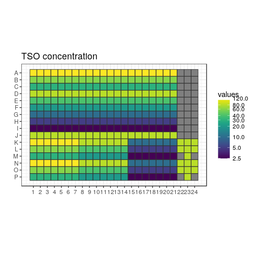

```r
(plot_TSO <- plateMapLog("TSO", "TSO concentration"))
```

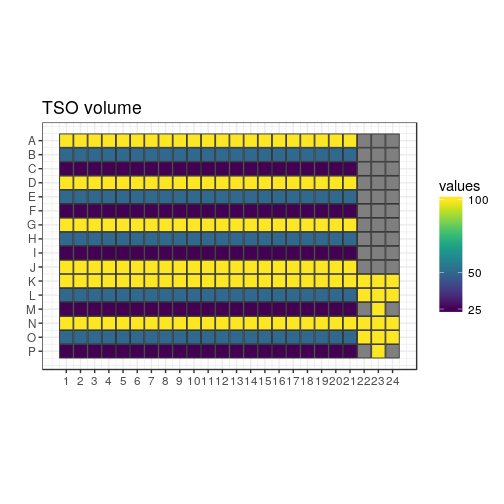

```r
(plot_TSO_vol <- plateMap("TSO_vol", "TSO volume"))
```

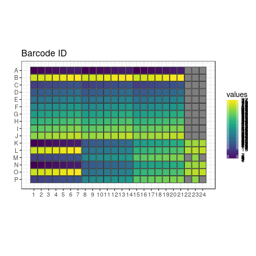

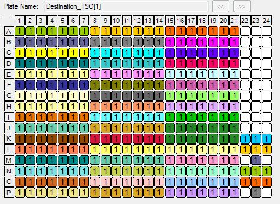

```r
(plot_BARCODES <- plateMap("BARCODE_ID", "Barcode ID"))
```

## H2O

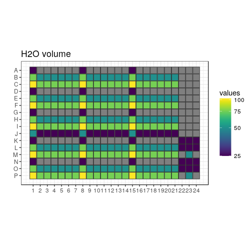

```r
(plot_H2O_vol <- plateMapLog("H2O_vol", "H2O volume"))
```

## RT primers

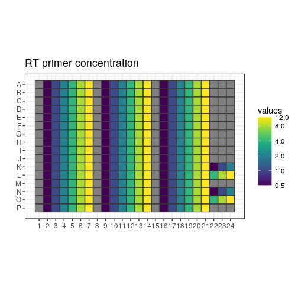

```r
(plot_RT <- plateMapLog("RT_PRIMERS", "RT primer concentration"))
```

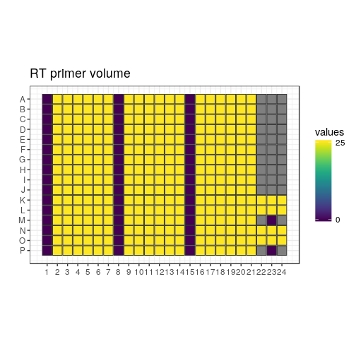

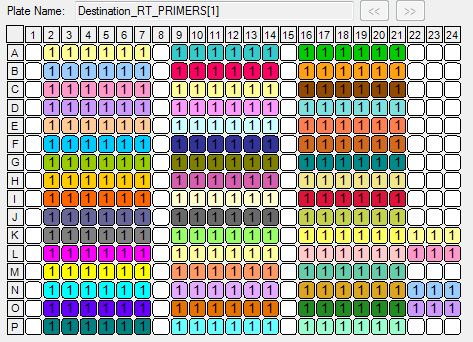

```r
(plot_RT_vol <- plateMap("RT_PRIMERS_vol", "RT primer volume"))
```

## Ratio TSO / RT

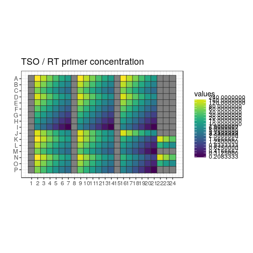

```r
(plot_TSO_RT_ratio <- platetools::raw_map(plate$TSO / plate$RT_PRIMERS, well=plate$well, plate="384") +
  ggtitle("TSO / RT primer concentration") +
  viridis::scale_fill_viridis(breaks = unique(plate$TSO / plate$RT_PRIMERS), trans = "log"))
```

## RNA mass

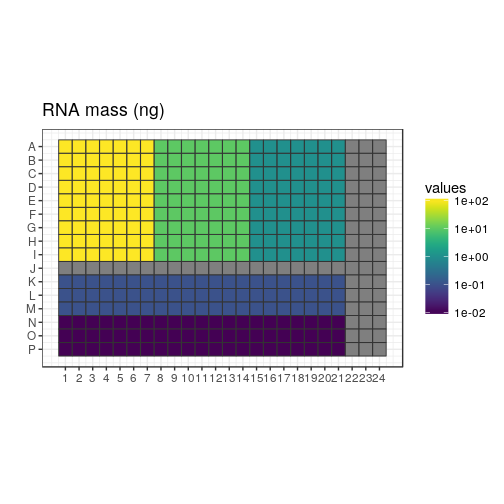

```r
(plot_RNA <- plateMapLog("RNA", "RNA mass (ng)"))
```

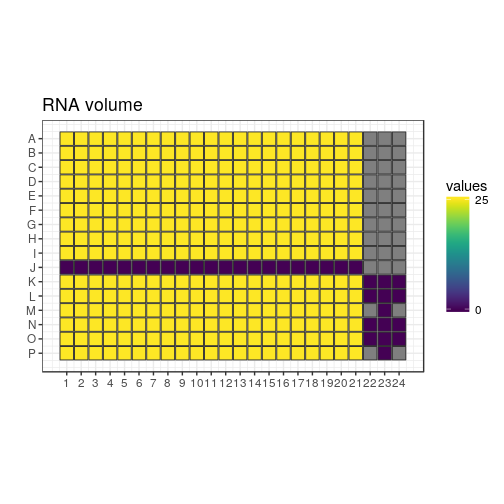

```r
(plot_RNA_vol <- plateMap("RNA_vol", "RNA volume"))
```

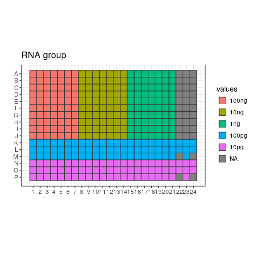

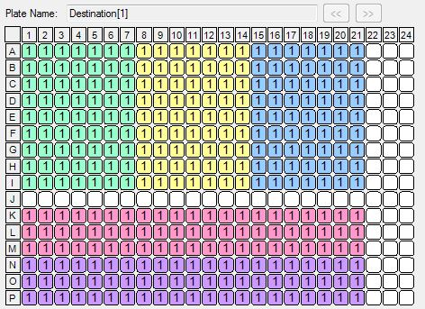

```r
(plot_RNA_group <- platetools::raw_map(plate[["RNA_group"]], well=plate$well, plate="384") +
  ggtitle("RNA group"))
```

## Concentrations

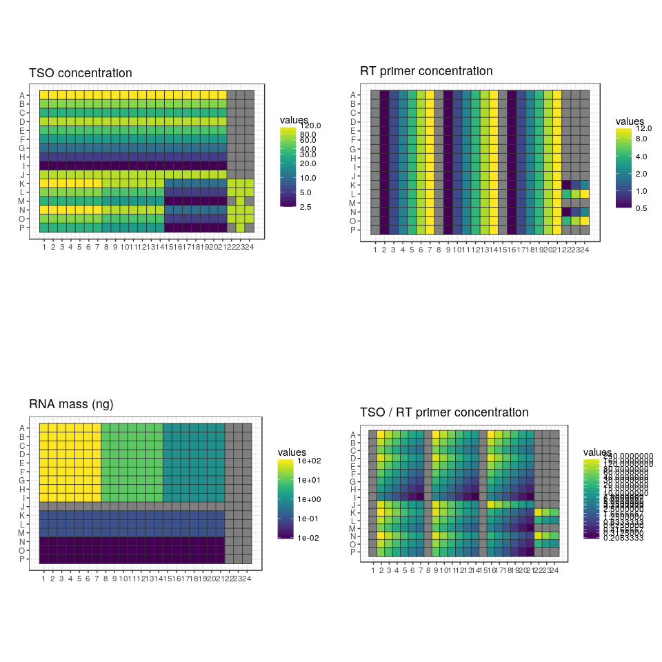

```r
ggpubr::ggarrange(ncol = 2, nrow = 2, plot_TSO, plot_RT, plot_RNA, plot_TSO_RT_ratio)
```

## Volumes

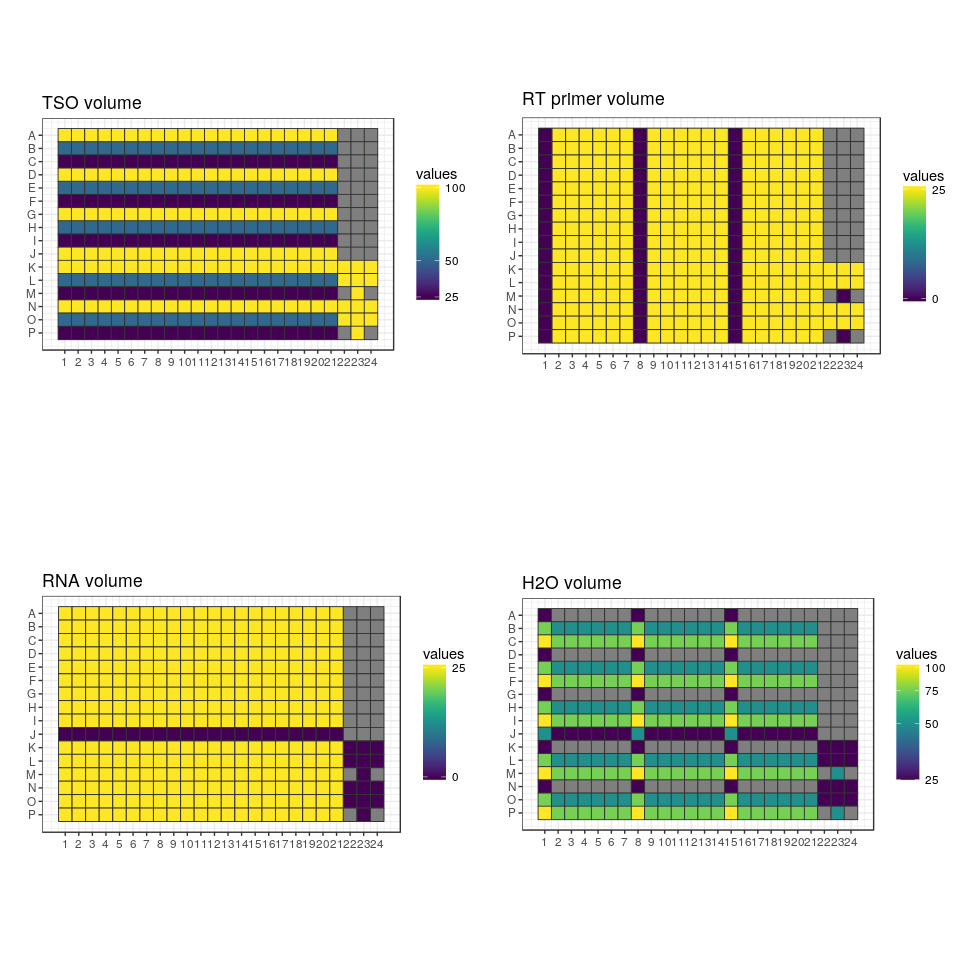

```r
ggpubr::ggarrange( ncol = 2, nrow = 2
                 , plot_TSO_vol, plot_RT_vol, plot_RNA_vol, plot_H2O_vol)
```